# Final Project

Data Science for Biologists, Spring 2021

Ashley Priore

## Introduction

The pizza barstool review dataset comprises customer reviews of many different pizzerias all throughout the USA. This dataset provides the name of the pizzeria, general aspects regarding location, and customer’s reviews based on pricing and overall experience. I chose this dataset because it interested me as I worked in a pizzeria for 5 years! I would like to further explore how different pizzerias are ranked in different areas. The link to this source is [Pizza](https://github.com/rfordatascience/tidytuesday/blob/master/data/2019/2019-10-01/pizza_barstool.csv).

```r
#reading in dataset
pizza_barstool <- readr::read_csv("https://raw.githubusercontent.com/rfordatascience/tidytuesday/master/data/2019/2019-10-01/pizza_barstool.csv")

#briefly viewing dataset
glimpse(pizza_barstool)
```

```
## Rows: 463
## Columns: 22
## $ name                                 <chr> "Pugsley's Pizza", "Williamsburg…
## $ address1                             <chr> "590 E 191st St", "265 Union Ave…
## $ city                                 <chr> "Bronx", "Brooklyn", "New York",…
## $ zip                                  <dbl> 10458, 11211, 10017, 10036, 1000…
## $ country                              <chr> "US", "US", "US", "US", "US", "U…
## $ latitude                             <dbl> 40.85877, 40.70808, 40.75370, 40…
## $ longitude                            <dbl> -73.88484, -73.95090, -73.97411,…
## $ price_level                          <dbl> 1, 1, 1, 2, 2, 1, 1, 1, 2, 2, 1,…
## $ provider_rating                      <dbl> 4.5, 3.0, 4.0, 4.0, 3.0, 3.5, 3.…
## $ provider_review_count                <dbl> 121, 281, 118, 1055, 143, 28, 95…
## $ review_stats_all_average_score       <dbl> 8.011111, 7.774074, 5.666667, 5.…
## $ review_stats_all_count               <dbl> 27, 27, 9, 2, 1, 4, 5, 17, 14, 6…
## $ review_stats_all_total_score         <dbl> 216.3, 209.9, 51.0, 11.2, 7.1, 1…
## $ review_stats_community_average_score <dbl> 7.992000, 7.742308, 5.762500, 0.…
## $ review_stats_community_count         <dbl> 25, 26, 8, 0, 0, 3, 4, 16, 13, 4…
## $ review_stats_community_total_score   <dbl> 199.8, 201.3, 46.1, 0.0, 0.0, 13…
## $ review_stats_critic_average_score    <dbl> 8.8, 0.0, 0.0, 4.3, 0.0, 0.0, 0.…
## $ review_stats_critic_count            <dbl> 1, 0, 0, 1, 0, 0, 0, 0, 0, 1, 0,…
## $ review_stats_critic_total_score      <dbl> 8.8, 0.0, 0.0, 4.3, 0.0, 0.0, 0.…
## $ review_stats_dave_average_score      <dbl> 7.7, 8.6, 4.9, 6.9, 7.1, 3.2, 6.…
## $ review_stats_dave_count              <dbl> 1, 1, 1, 1, 1, 1, 1, 1, 1, 1, 1,…
## $ review_stats_dave_total_score        <dbl> 7.7, 8.6, 4.9, 6.9, 7.1, 3.2, 6.…
```

## Question 1

#### How many pizzerias are within each price level?

### Methods

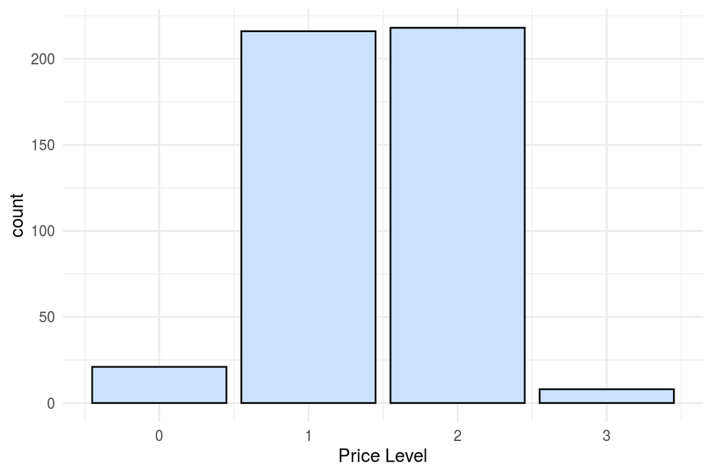

```r
pizza_barstool%>% #giving this dataset to ggplot
  ggplot()+ #about to make a plot
  aes(x=price_level)+ #specifying x axis
  geom_bar(color= "black", fill="lightsteelblue1")+ #specifying type of plot, color, and fill
  labs(x= "Price Level")+ #appropriate labeling and price level: 0= no $ (least expensive), 1=$, 2=$$, 3=$$$ (most expensive)+
  theme_minimal() #specifying theme
```

```r
pizza_barstool%>% #giving this dataset to next function
  count(price_level) #counting number of times each price level appears- using this code to help answer question
```

```
## # A tibble: 4 x 2
##   price_level     n
## *       <dbl> <int>
## 1           0    21
## 2           1   216
## 3           2   218
## 4           3     8
```

### Answer

The number of pizzerias surveyed that are within each price level are as follows: price level 0 (least expensive)= 21, price level 1= 216, price level 2= 218, and price level 3 (most expensive)= 8.

## Question 2

#### What is the relationship bewteen latitude and longitude of these pizzerias?

### Methods

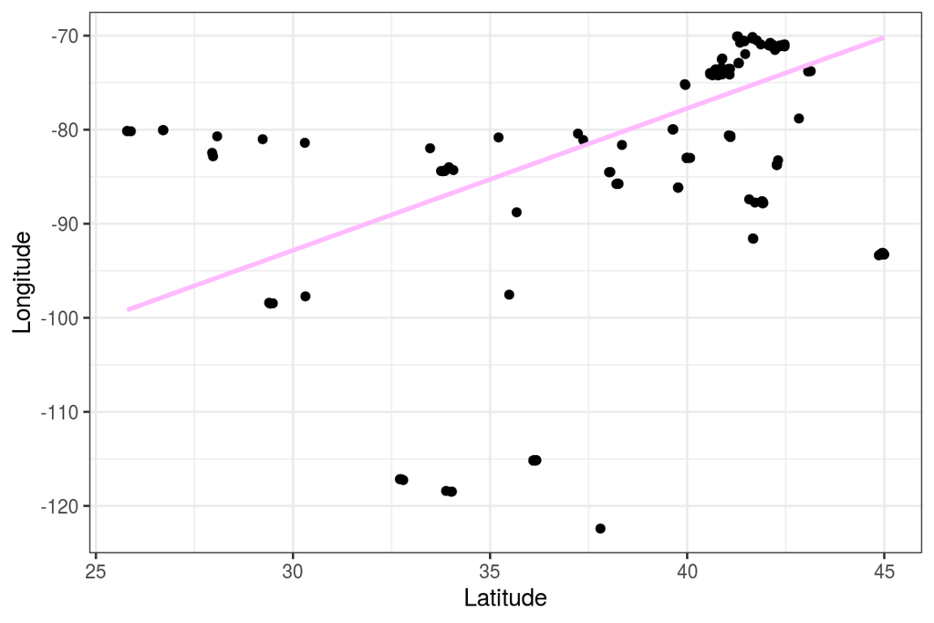

```r
pizza_barstool%>% #giving this dataset to next function
  ggplot()+ #about to make a plot
  aes(x=latitude, y=longitude)+ #specifying x and y axis
  geom_point()+ #specifying type of plot
  geom_smooth(method="lm", se= FALSE, color="plum1")+ #adding in smooth trendline and specifying color
  labs(x= "Latitude", y= "Longitude")+ #appropriate labeling
  theme_bw() #indicating theme
```

### Answer

There is a positive relationship between latitude and longitude of the given pizzerias as shown with the trendline.

## Question 3

#### Does a price level of 2 have a higher total critic score compared to a price level of 1?

### Methods

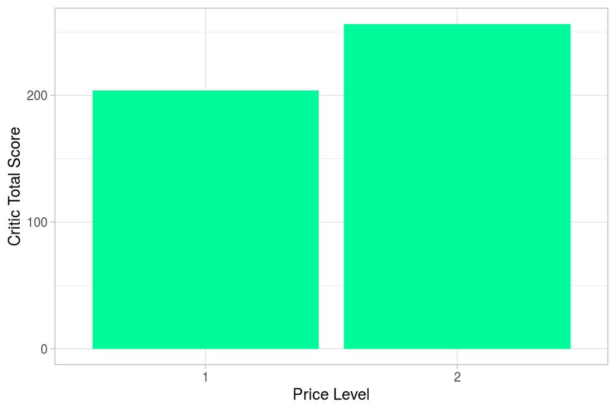

```r
pizza_barstool%>% #giving this dataset to next function
  rename(critic_total_score= review_stats_critic_total_score)%>% #renaming column for easier use
  filter(price_level %in% c("1","2"))%>% #keeping only price levels of 1 and 2
  ggplot()+ #about to make a plot
  aes(x=as.factor(price_level), y=critic_total_score)+ #specifying x and y axis and treat x like a FACTOR
  geom_col(fill= "mediumspringgreen")+ #specifying type of plot and fill
  labs(x= "Price Level", y= "Critic Total Score")+ #appropriate labeling
  theme_light() #indicating theme
```

### Answer

Price level of 2 does have a higher critic total score than compared to price level 1 meaning that the professional critics of these pizzerias enjoyed the overall experience at a pizzeria that costed slightly more money.

## Question 4

#### What is the distribution of Dave’s total score?

### Methods

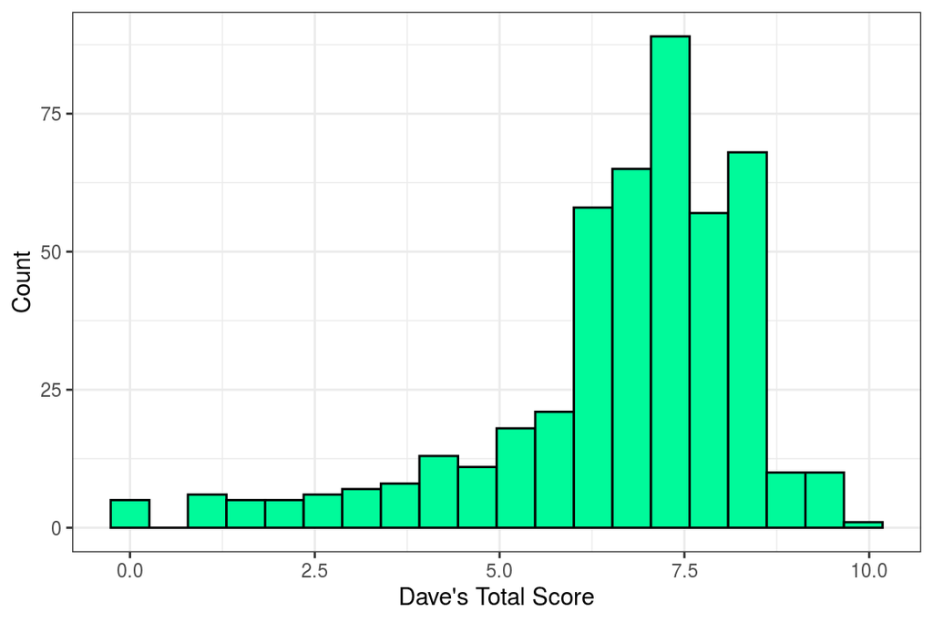

```r
pizza_barstool%>% #giving this dataset to next function
  rename(dave_total_score= review_stats_dave_total_score)%>% #renaming column for easier use
  ggplot()+ #about to make a plot
  aes(x=dave_total_score)+ #specifying x axis
  geom_histogram(fill= "mediumspringgreen", color= "black", bins=20)+ #specifying type of plot and fill, color, and number of bins
  labs(x= "Dave's Total Score", y= "Count")+ #appropriate labeling
  theme_bw() #indicating theme
```